# Correction TD2

Pierre-O Goffard

17 janvier 2019

## TD 2

### Exercice 1

#### 1)

Nous allons étudier le lien entre taille du moteur et l’efficacité de la consommation d’essence à l’aide du jeu de données **mpg** de la librairie **ggplot2**. Donner le code R permettant de générer la courbe suivante (incluant le nom des axes et le chargement des données).

```r
library(ggplot2)
data(mpg)
help(mpg)
```

```
## starting httpd help server ... done
```

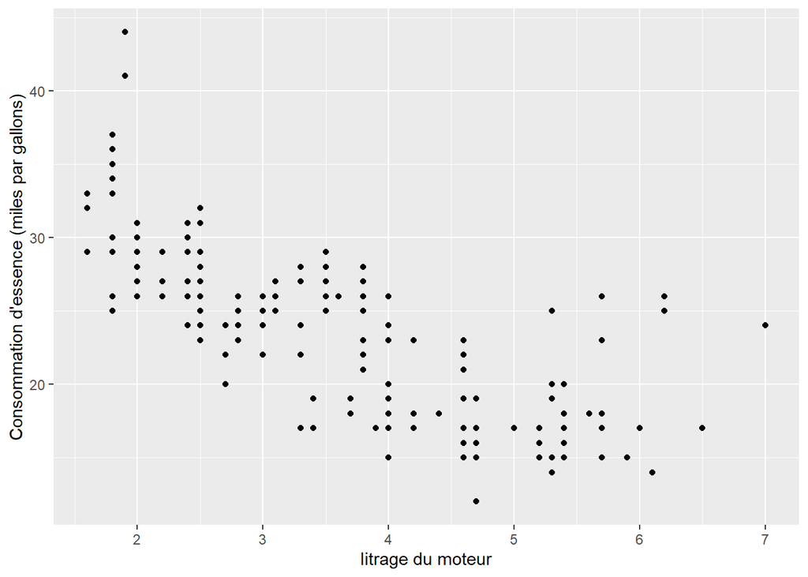

```r
ggplot(data = mpg) + geom_point(mapping = aes(x = displ  , y  = hwy)) + xlab('litrage du moteur') + ylab("Consommation d'essence (miles par gallons)")
```

### 2) On reprend le graphique précédent et on assigne une couleur différente en fonction des modalités sur la variable **class**. Copier et coller votre résultat. Commenter le graphique.

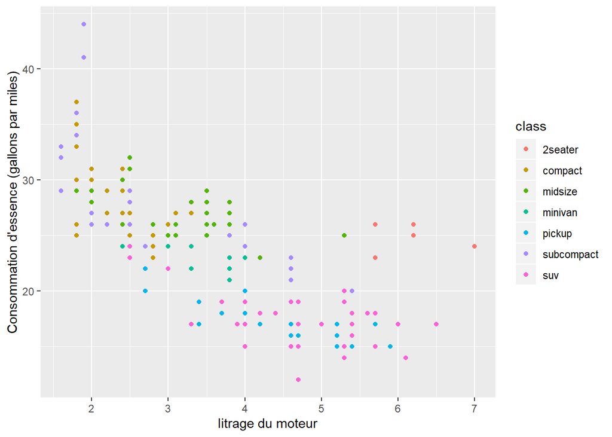

```r
ggplot(data = mpg) + geom_point(mapping = aes(x = displ  , y  = hwy, colour = class)) + xlab('litrage du moteur') + ylab("Consommation d'essence (gallons par miles)")
```

## Exo 2

### 1)

Tracer la densité et la fonction de répartition de la loi normale de moyenne 0 et d’écart-type 1 dans deux graphiques l’un à côté de l’autre. Ajouter

- un titre sur chaque graphe et veillez à ce que celui-ci soit centré
- la densité doit etre tracée en rouge
- la fonction de répartition doit être tracée en bleue

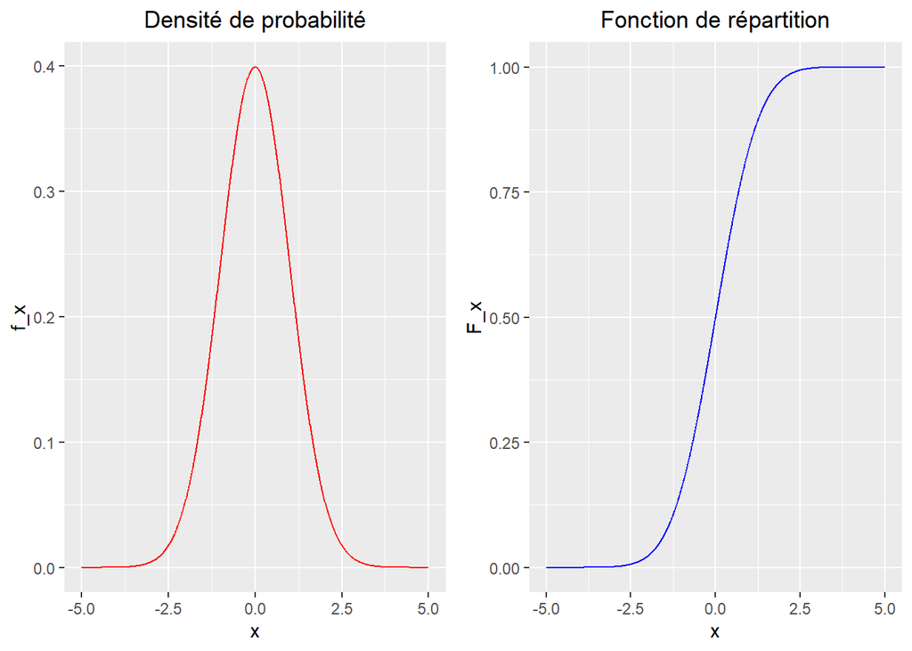

```r
library(gridExtra)
# Valeur de la densit? de probabilit?
normal_pdf = data.frame(grid = seq(-5, 5, 0.01), f_x = dnorm(seq(-5, 5, 0.01)), F_x = pnorm(seq(-5, 5, 0.01)))
pdf_plot <- ggplot(data = normal_pdf) + geom_line(mapping = aes(x = grid, y = f_x), color = 'red') + xlab('x') +
  ggtitle('Densité de probabilité') + theme(plot.title = element_text(hjust = 0.5))
cdf_plot <- ggplot(data = normal_pdf) + geom_line(mapping = aes(x = grid, y = F_x), color = 'blue') + xlab('x') +
  ggtitle('Fonction de répartition') + theme(plot.title = element_text(hjust = 0.5))
grid.arrange(pdf_plot, cdf_plot, ncol=2)
```

### 2)

Tracer sur un même graphique la densité de la loi normale

- de moyenne $1$ et d’écart type $3$
- de moyenne $-1$ et d’écart-type $0.5$
- de moyenne $0$ et d’écart-type $1$

Chaque courbe doit être de couleur différente, et il faut une légende pour accompagner le graphique

Mettez simplement l’image.

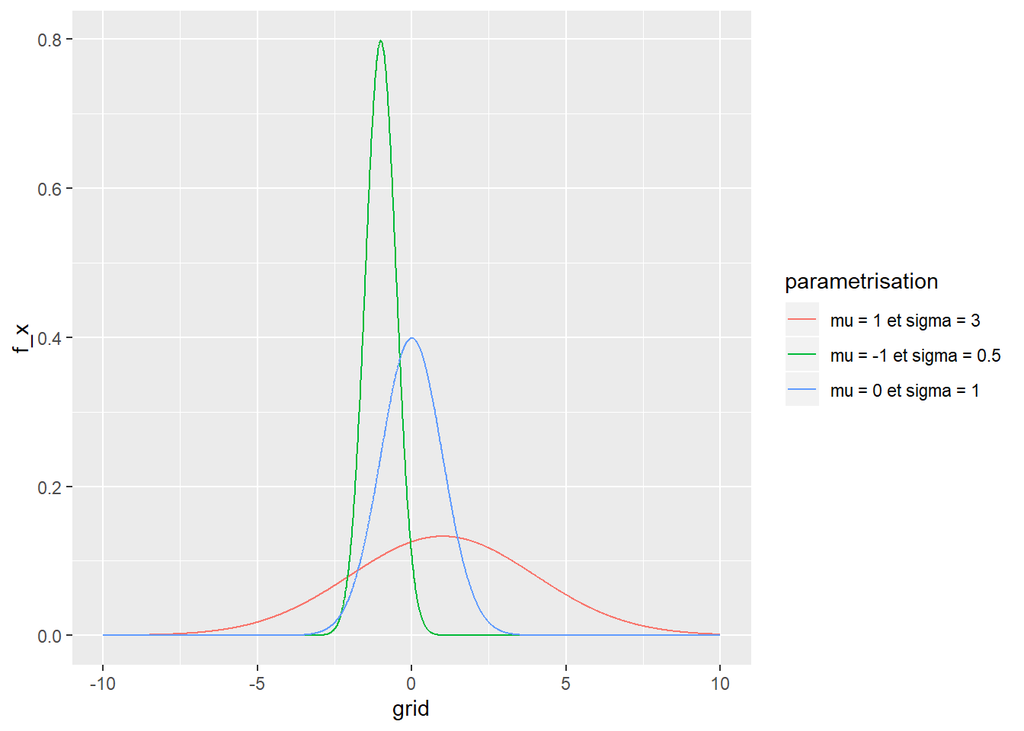

```r
normal_pdf_1_3 = data.frame(grid = seq(-10, 10, 0.01), f_x = dnorm(seq(-10, 10, 0.01), mean = 1, sd = 3), parametrisation =  'mu = 1 et sigma = 3')
normal_pdf_moins1_0.5 = data.frame(grid = seq(-10, 10, 0.01), f_x = dnorm(seq(-10, 10, 0.01), mean = -1, sd = 0.5), parametrisation =  'mu = -1 et sigma = 0.5')
normal_pdf_0_1 = data.frame(grid = seq(-10, 10, 0.01), f_x = dnorm(seq(-10, 10, 0.01), mean = 0, sd = 1), parametrisation =  'mu = 0 et sigma = 1')
normal_pdfs = rbind(normal_pdf_1_3, normal_pdf_moins1_0.5, normal_pdf_0_1)
ggplot(data = normal_pdfs) + geom_line(mapping = aes(x = grid, y = f_x, color = parametrisation))
```

## Exo 3

### 1)

Simuler un échantillon de taille $1000$ de loi de Bernoulli de paramètre $p=0.6$. Calculer les moyennes successives $M_l = S_l / l$, avec $S_l =\sum_{k=1}^{l}x_k$ et $l=1,\ldots, 1000$ et tracer $M_l$ en fonction des valeurs de $l$. J’aimerais un nuage de points reliés.

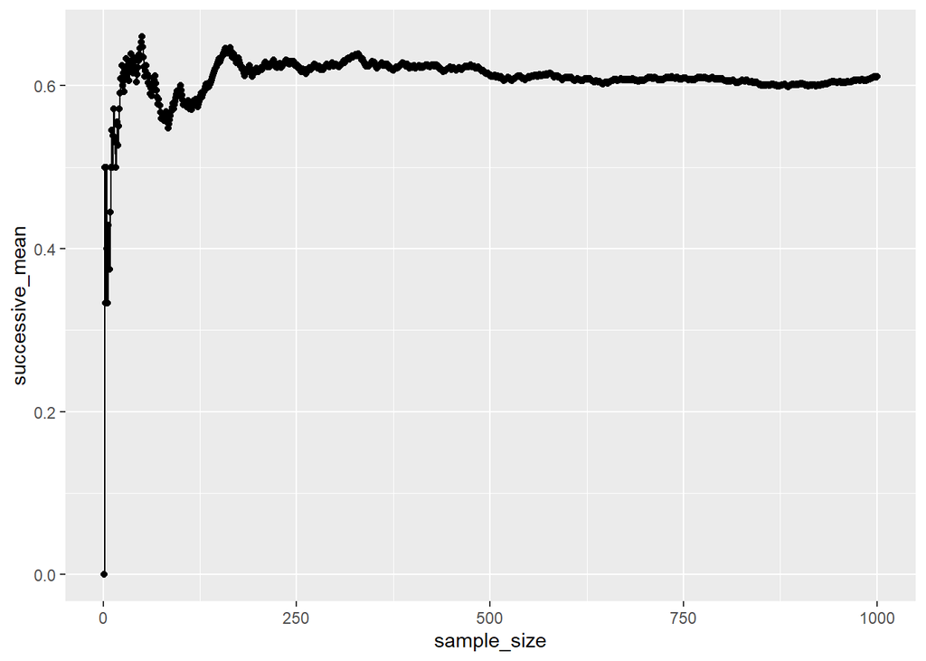

```r
# Echantillon de loi de Bernouilli
sample_Bernoulli <- rbinom(1000, size = 1, prob = 0.6)
# Moyenne successive
successive_mean <- cumsum(sample_Bernoulli)/(1:1000)
# On crée le data frame
successive_mean_df <- data.frame(sample_size = 1:1000, successive_mean)
# On trace la courbe des moyennes successives
ggplot(data = successive_mean_df, mapping = aes(x = sample_size, y = successive_mean)) +
  geom_point() + geom_line()
```

### 2)

Générer des échantillons $S_1, \ldots, S_{1000}$ de taille $1000$ de loi binomiale de paramètres $p = 0.5$ et

- $N = 10$
- $N = 30$
- $N = 1000$

Stocker dans trois vecteurs (**U10**, **U30** et **U1000**) les quantités
$$\frac{S_i- Np}{\sqrt{Np(1-p)}},\text{ }i = 1,\ldots 1000.$$
pour chaque valeur de $N\in\{10,30,1000\}$. Tracer les histogrammes pour chacune des valeurs de $N$ et placer les les uns à côté des autres. Ajouter par dessus l’histogramme la desnité de la loi normal de moyenne 0 et d’écart type 1. Faites bien attention à l’échelle de l’axe des Y de l’histogramme.

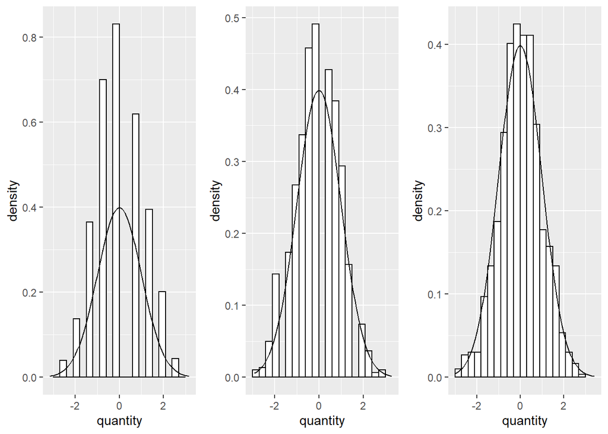

```r
library(gridExtra)
# Echantillon de loi binomiale avec leur paramètre de taille
binom_samples = lapply(c(10,30,1000), function(N) list(N, rbinom(1000, size = N, prob = 1/2)))
# Les quantités demandées dans l'énoncé
quantities = lapply(binom_samples, function(bin_samp) data.frame( quantity = (bin_samp[[2]]- bin_samp[[1]]/2) / sqrt(bin_samp[[1]] / 4)))
# Les trois histogrammes
hist_1 <- ggplot(quantities[[1]], aes(x = quantity)) +
  geom_histogram(aes(y = ..density..),
                 breaks = seq(-3, 3, by = 0.3),
                 colour = "black",
                 fill = "white") +
  # La fonction stat_function permet d'ajouter une courbe de référence
   stat_function(fun = dnorm, args = list(mean = 0, sd = 1))
hist_2 <- ggplot(quantities[[2]], aes(x = quantity)) +
  geom_histogram(aes(y = ..density..),
                 breaks = seq(-3, 3, by = 0.3),
                 colour = "black",
                 fill = "white") +
   stat_function(fun = dnorm, args = list(mean = 0, sd = 1))
hist_3 <- ggplot(quantities[[3]], aes(x = quantity)) +
  geom_histogram(aes(y = ..density..),
                 breaks = seq(-3, 3, by = 0.3),
                 colour = "black",
                 fill = "white") +
   stat_function(fun = dnorm, args = list(mean = 0, sd = 1))
grid.arrange(hist_1, hist_2, hist_3, ncol=3)
```

## Exercice 4

### 1)

Charger le jeu de données **Datacar** via le Package **insuranceData**. Nous allons étudier l’occurence de sinistres en fonction du genre. Sur un même graphique, afficher un diagramme en barre pour chaque modalité de la variable **gender** pour étudier la répartition des modalités sur la variable **clm** au sein des classe définie par la variable **gender**. Sur le graphique donner au dessus de chaque bar le pourcentage ligne/colonne correspondant (c’est à dire pour la barre associée à la modalité ‘F’ sur la variable **gender** et ‘0’ sur la variable **clm**, donner la proportion de modalité ‘0’ parmi les observations admettant la modalité ‘F’)

```r
library(questionr)
library(insuranceData)
library(scales)
data("dataCar")
names(dataCar)
```

```
##  [1] "veh_value" "exposure"  "clm"       "numclaims" "claimcst0" "veh_body"
##  [7] "veh_age"   "gender"    "area"      "agecat"    "X_OBSTAT_"
```

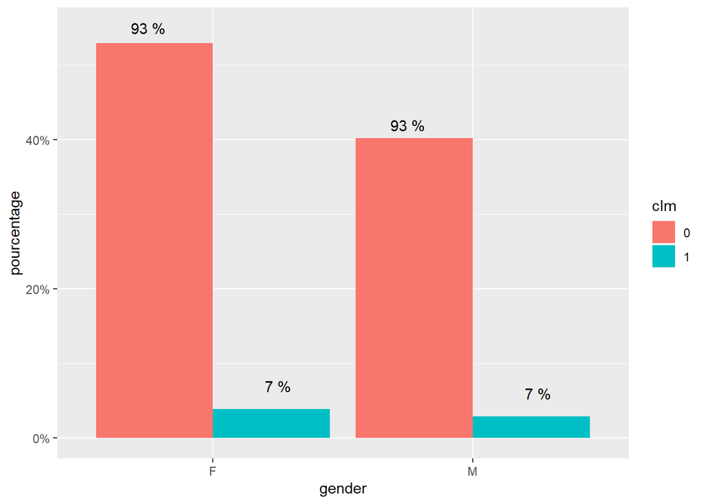

```r
# Transformation de la variable clm en variable catégorielle
dataCar$clm <- as.factor(dataCar$clm)
# Tableau de contingence
tab <- table(dataCar$gender, dataCar$clm)
pourcentage_ligne <- lprop(tab)
# Diagramme en bar
ggplot(data = dataCar) + geom_bar(mapping = aes(x = gender, y = (..count..)/sum(..count..), fill = clm), position = 'dodge') +
  # Pour afficher les valeurs sous le format pourcentage
  scale_y_continuous(labels = percent) + ylab('pourcentage') +
  annotate("text", x=0.75, y=0.55, label= paste(round(pourcentage_ligne[1,1]), '%')) +
  annotate("text", x=1.25, y=0.07, label= paste(round(pourcentage_ligne[1,2]), '%')) +
  annotate("text", x=1.75, y=0.42, label= paste(round(pourcentage_ligne[2,1]), '%')) +
  annotate("text", x=2.25, y=0.06, label= paste(round(pourcentage_ligne[2,2]), '%'))
```

```r
ggsave("Diagramme_barre_Sinistralité.png")
```

### 2)

Mettre côte à côte l’histogramme et la boîte à moustache associés à la distribution du montant des sinistres (**claimcst0**) et en dessous l’histogramme et la boîte à moustache de la distribution des montants de sinitres non nuls.

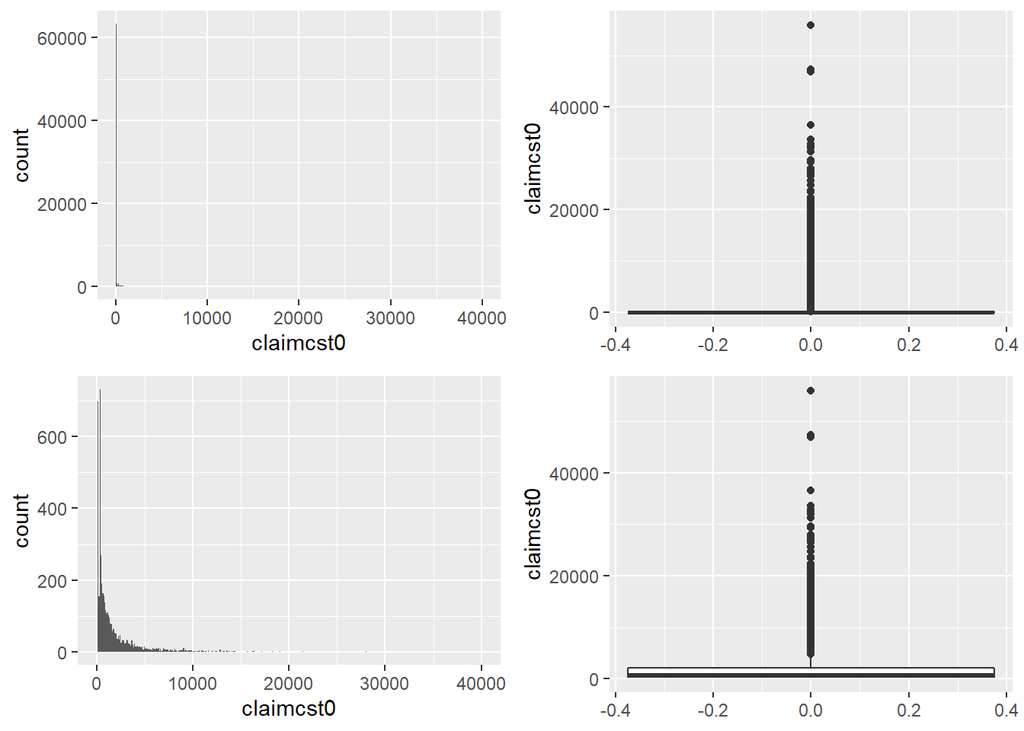

```r
library(gridExtra)
histogram <- ggplot(data = dataCar) + geom_histogram(aes(claimcst0), breaks = seq(0, 40000, 100))
boxplot <- ggplot(data = dataCar) + geom_boxplot(mapping = aes(y = claimcst0))
histogram_1 <- ggplot(data = dataCar[dataCar$clm == 1, ]) + geom_histogram(aes(claimcst0), breaks = seq(0, 40000, 100))
boxplot_1 <- ggplot(data = dataCar[dataCar$clm == 1, ]) + geom_boxplot(mapping = aes(y = claimcst0))
grid.arrange(histogram, boxplot, histogram_1, boxplot_1, ncol = 2)
```

### 3) Tracer sur un même graphique la boîte à moustache des montants de sinistres non nuls pour chacune des modalités de la variable **gender**. Ajouter une ligne horizontale pour indiquer où se situe la moyenne pour chacune des modalités sur la variable **gender**. Les lignes horizontales doivent être de couleur différente.

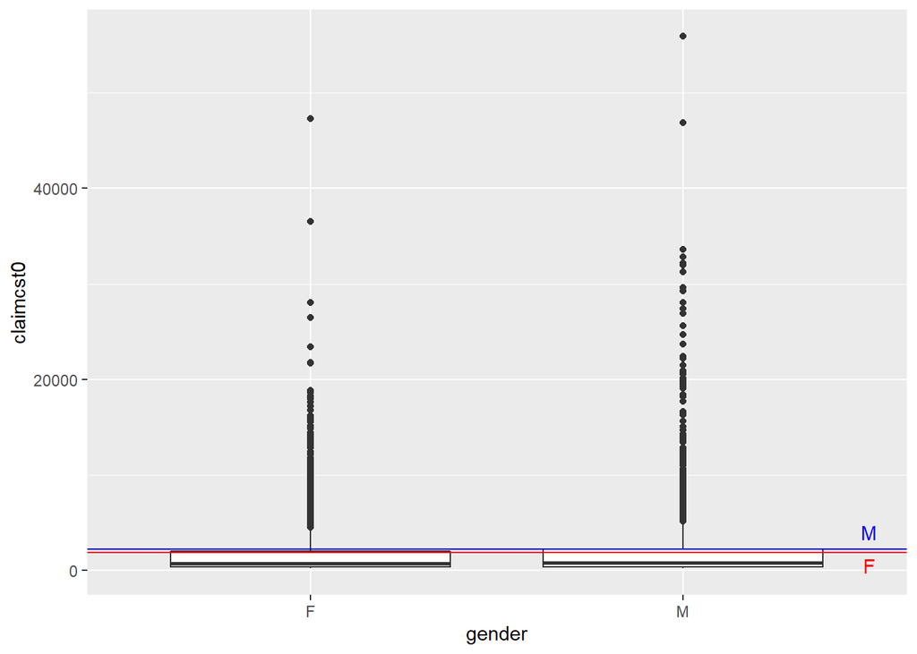

```r
ggplot(data = dataCar[dataCar$clm == 1, ]) + geom_boxplot(mapping = aes(y = claimcst0, x = gender)) + geom_hline(yintercept = mean(dataCar$claimcst0[(dataCar$clm == 1)&(dataCar$gender == 'M')]), color = 'blue') + geom_hline(yintercept = mean(dataCar$claimcst0[(dataCar$clm == 1)&(dataCar$gender == 'F')]), color = 'red') +
  annotate("text", x = 2.5, y = 4000 , label = 'M', color = 'blue') +
  annotate("text", x = 2.5, y = 500, label = 'F', color = 'red')
```